# Chapter 5: Dimensionality reduction techniques

## Exploring dataset

Read in the data and visualize with ggpairs and spearman correlations.

```r
library(data.table)
library(GGally)
library(corrplot)
library(dplyr)
human<-read.table("http://s3.amazonaws.com/assets.datacamp.com/production/course_2218/datasets/human2.txt", row.names=1, header=T, sep=",")
summary(human)
```

```
##     Edu2.FM          Labo.FM          Edu.Exp         Life.Exp
##  Min.   :0.1717   Min.   :0.1857   Min.   : 5.40   Min.   :49.00
##  1st Qu.:0.7264   1st Qu.:0.5984   1st Qu.:11.25   1st Qu.:66.30
##  Median :0.9375   Median :0.7535   Median :13.50   Median :74.20
##  Mean   :0.8529   Mean   :0.7074   Mean   :13.18   Mean   :71.65
##  3rd Qu.:0.9968   3rd Qu.:0.8535   3rd Qu.:15.20   3rd Qu.:77.25
##  Max.   :1.4967   Max.   :1.0380   Max.   :20.20   Max.   :83.50
##       GNI            Mat.Mor         Ado.Birth         Parli.F
##  Min.   :   581   Min.   :   1.0   Min.   :  0.60   Min.   : 0.00
##  1st Qu.:  4198   1st Qu.:  11.5   1st Qu.: 12.65   1st Qu.:12.40
##  Median : 12040   Median :  49.0   Median : 33.60   Median :19.30
##  Mean   : 17628   Mean   : 149.1   Mean   : 47.16   Mean   :20.91
##  3rd Qu.: 24512   3rd Qu.: 190.0   3rd Qu.: 71.95   3rd Qu.:27.95
##  Max.   :123124   Max.   :1100.0   Max.   :204.80   Max.   :57.50
```

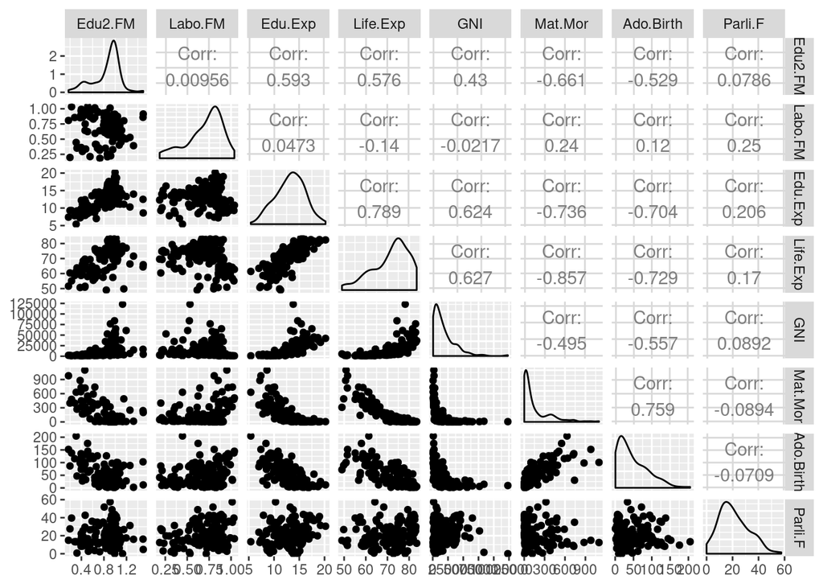

```r
ggpairs(human)
```

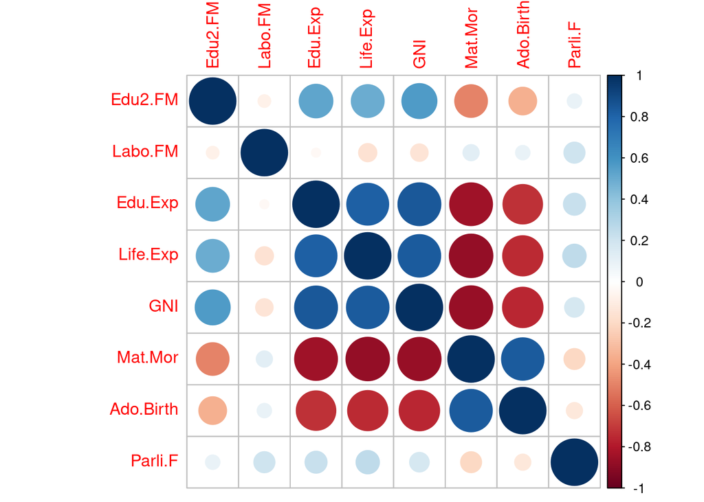

```r
corrplot(cor(human, method="spearman"))
```

All variables seem to be unimodal and most have skewed non-normal distributions, some with heavy tails. Potentially only Edu.Exp could be approximated properly with a normal distribution. Correlation among Edu2FM, Edu.Exp, Life.Exp, GNI, Mat.Mor, and Ado.Birth seem high (both positive and negative directions). Labo.FM and Parli.F do not seem to strongly correlate with other variables, and they’re conceptually also different, they describe society level differences, whereas prior variables are conceptually individual level.

## PCA

Next we were asked to perform a PCA and draw a biplot using raw and then with scaled data. (Scaling non-normal distributions using standard deviations and mean can be considered somehwat questionnable, but let’s follow the assignment).

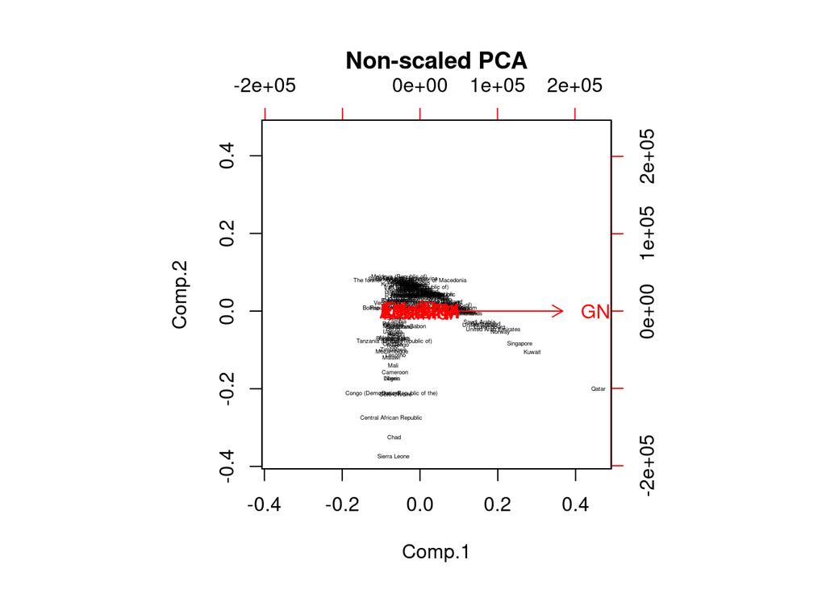

```r
pc<-princomp(human)
biplot(pc, cex=c(0.3, 1), main="Non-scaled PCA")
```

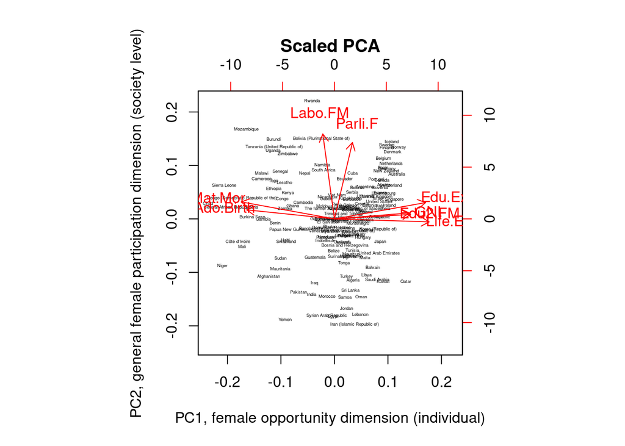

```r
pc<-princomp(scale(human))
biplot(pc, cex=c(0.3, 1), main="Scaled PCA", xlab="PC1, female opportunity dimension (individual)", ylab="PC2, general female participation dimension (society level)")
```

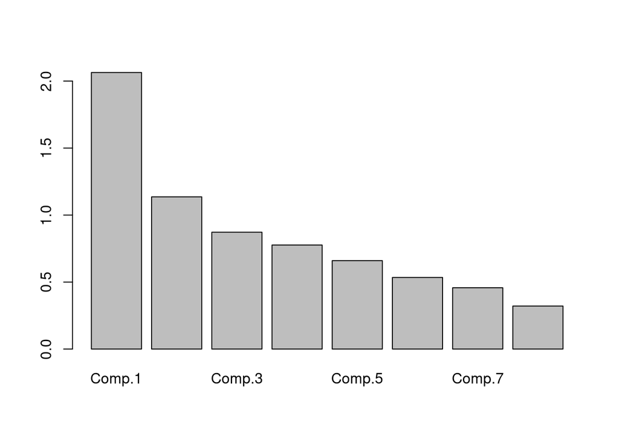

```r
barplot(pc$sdev)
```

```r
summary(pc)
```

```
## Importance of components:
##                           Comp.1    Comp.2     Comp.3     Comp.4
## Standard deviation     2.0641471 1.1360379 0.87222124 0.77634649
## Proportion of Variance 0.5360463 0.1623703 0.09571374 0.07582845
## Cumulative Proportion  0.5360463 0.6984166 0.79413031 0.86995876
##                            Comp.5     Comp.6     Comp.7     Comp.8
## Standard deviation     0.65981755 0.53457325 0.45751637 0.32119948
## Proportion of Variance 0.05477328 0.03595302 0.02633506 0.01297988
## Cumulative Proportion  0.92473204 0.96068506 0.98702012 1.00000000
```

The non-scaled PCA seems to be highly driven by GNI because it has large absolute variance compared to other variables. Thus, some kind of scaling makes sense, to give all variables same original weight to start with.

In scaled PCA, x-dimension seems to gather variables that are related to individual level freedom / opportunities of women (explains 53% of variance). The y-axis seems to map variables that indicate general society participation level (i.e. politics) of women (explains 16% of variance). Together these two first PCs explain nearly 70% of all variance.

## MCA and Tea data

```r
library(FactoMineR)
data(tea)
glimpse(tea)
```

```
## Observations: 300
## Variables: 36
## $ breakfast        <fct> breakfast, breakfast, Not.breakfast, Not.brea...
## $ tea.time         <fct> Not.tea time, Not.tea time, tea time, Not.tea...
## $ evening          <fct> Not.evening, Not.evening, evening, Not.evenin...
## $ lunch            <fct> Not.lunch, Not.lunch, Not.lunch, Not.lunch, N...
## $ dinner           <fct> Not.dinner, Not.dinner, dinner, dinner, Not.d...
## $ always           <fct> Not.always, Not.always, Not.always, Not.alway...
## $ home             <fct> home, home, home, home, home, home, home, hom...
## $ work             <fct> Not.work, Not.work, work, Not.work, Not.work,...
## $ tearoom          <fct> Not.tearoom, Not.tearoom, Not.tearoom, Not.te...
## $ friends          <fct> Not.friends, Not.friends, friends, Not.friend...
## $ resto            <fct> Not.resto, Not.resto, resto, Not.resto, Not.r...
## $ pub              <fct> Not.pub, Not.pub, Not.pub, Not.pub, Not.pub, ...
## $ Tea              <fct> black, black, Earl Grey, Earl Grey, Earl Grey...
```

[output cut: 23 more lines]

All variables seem to be multinomial / categorical apart from age variable, and most are not ordered. The proper way to assess their relationships is not through correlations but using e.g. Cramer’s V:

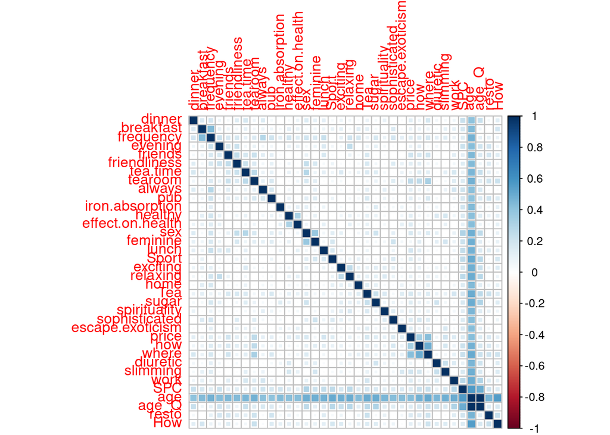

```r
library(vcd)
tmp<-lapply(1:ncol(tea), function(i) sapply(1:ncol(tea), function(j) {assocstats(table(tea[,i], tea[,j]))$cramer}) )
kor<-as.matrix(as.data.frame(tmp))
rownames(kor)<-colnames(tea)
colnames(kor)<-colnames(tea)
corrplot(kor, order="hclust", method="square")
```

We can see that age seems to be related to all other variables. Also where, price, and how form correlated cluster as well as breakfast and frequency.

Let’s conduct multiple correspondence analysis. Data description says: “The data used here concern a questionnaire on tea. We asked to 300 individuals how they drink tea (18 questions), what are their product’s perception (12 questions) and some personal details (4 questions).”

Furhtermore, “The first 18 questions are active ones, the 19th is a supplementary quantitative variable (the age) and the last variables are supplementary categorical variables.”

Thus, let’s set last variables (starting from 19) as supplementary ones (age, col 19, as quantitative).

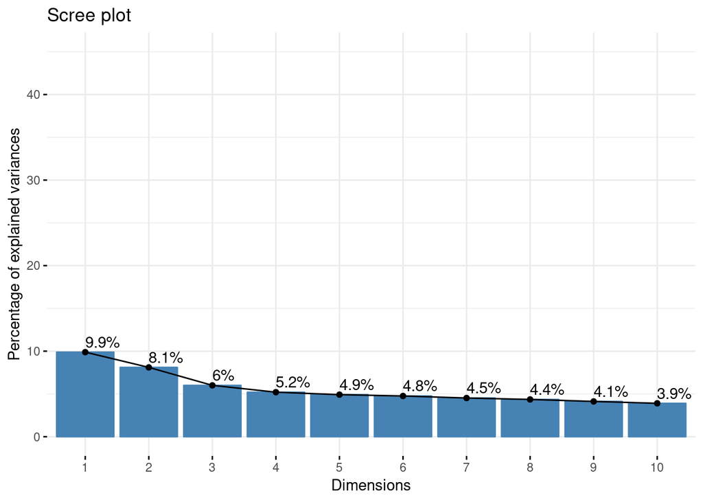

```r
library(factoextra)

mod1<-MCA(tea,quanti.sup=19,quali.sup=20:36, graph=F)
fviz_screeplot(mod1, addlabels = TRUE, ylim = c(0, 45))
```

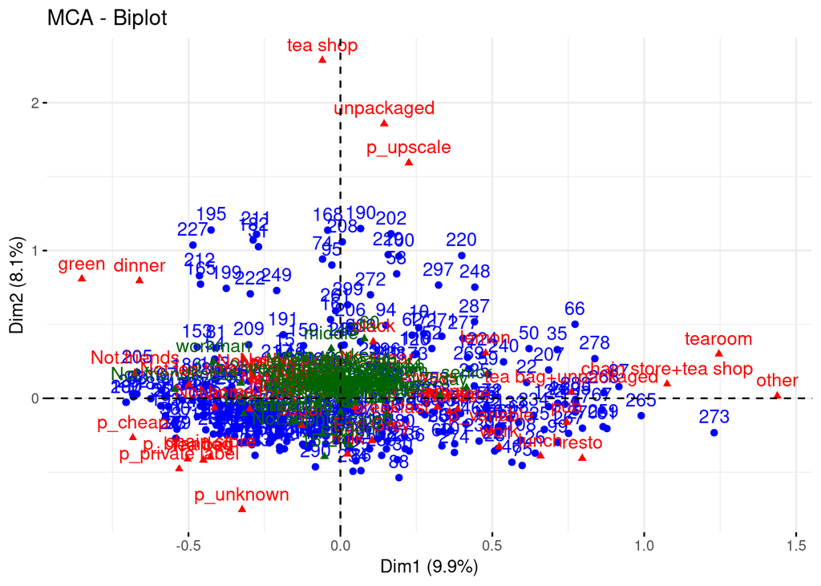

```r
fviz_mca_biplot(mod1,
               repel = F, # Avoid text overlapping (slow if many point)
               ggtheme = theme_minimal())
```

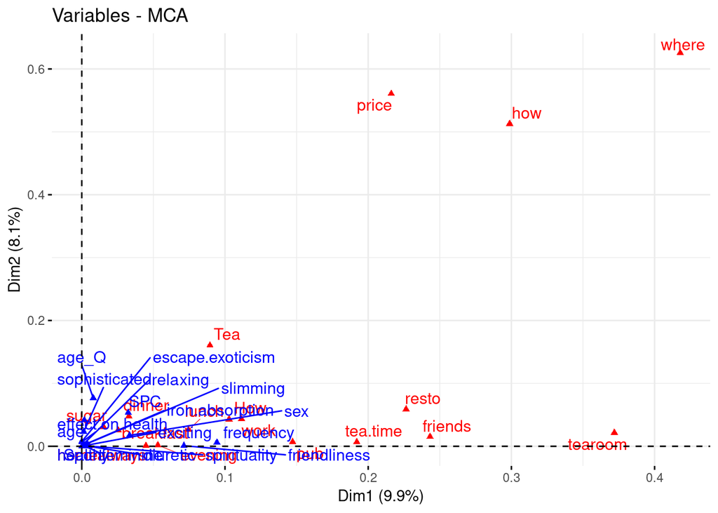

```r
fviz_mca_var(mod1, choice = "mca.cor",
            repel = TRUE, # Avoid text overlapping (slow)
            ggtheme = theme_minimal())
```

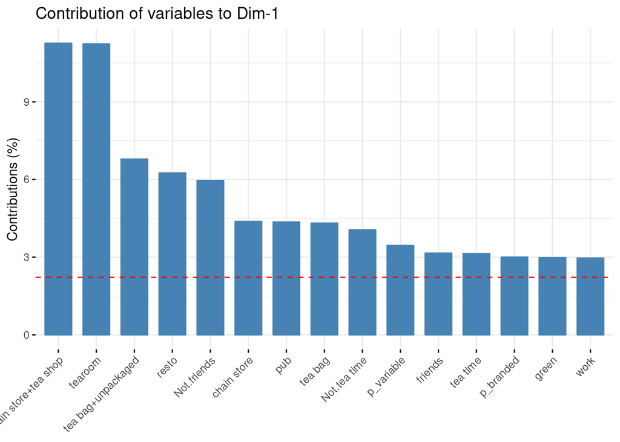

```r
# Contributions of rows to dimension 1
fviz_contrib(mod1, choice = "var", axes = 1, top = 15)
```

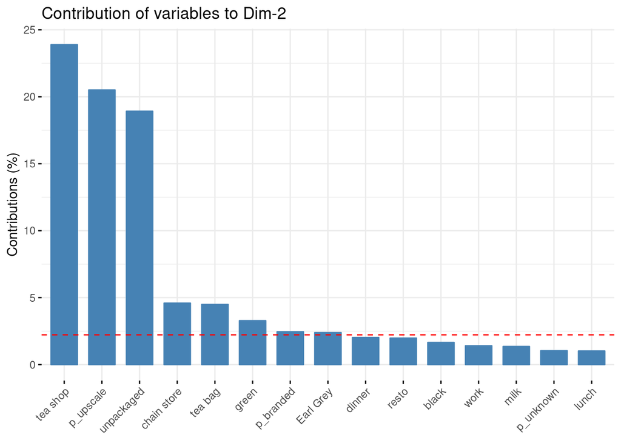

```r
# Contributions of rows to dimension 2
fviz_contrib(mod1, choice = "var", axes = 2, top = 15)
```

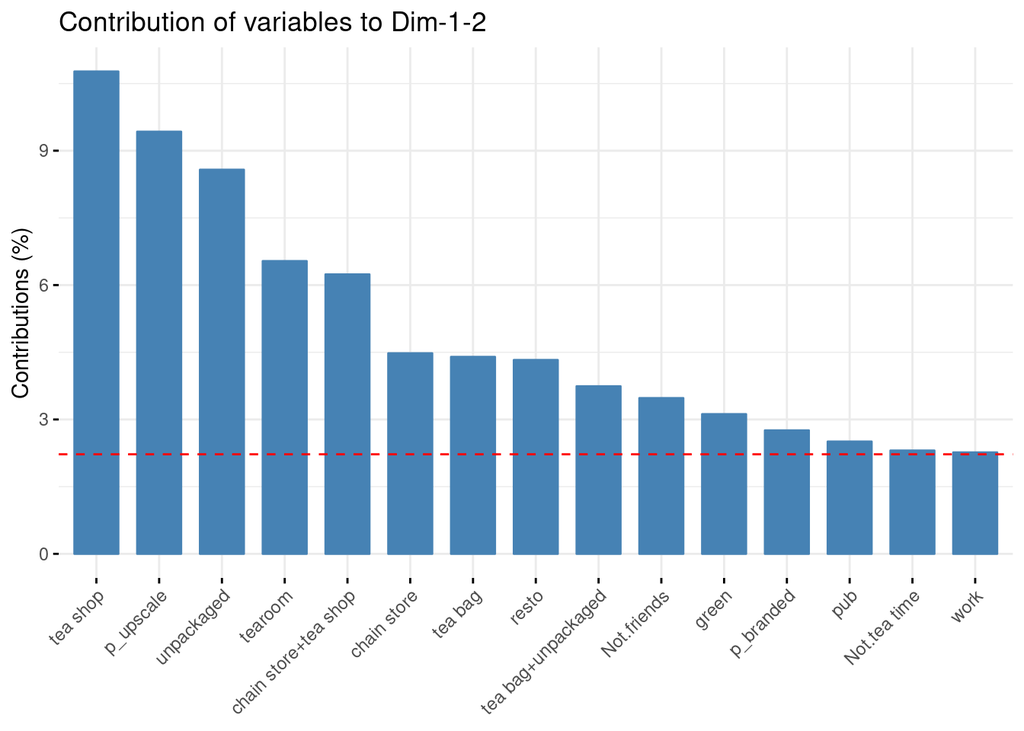

```r
# Total contribution to dimension 1 and 2
fviz_contrib(mod1, choice = "var", axes = 1:2, top = 15)
```

### Dim1: 10 Most correlated variables

```r
head(dimdesc(mod1, axes = c(1,2))[[1]]$quali, 10)
```

```
##                 R2      p.value
## where    0.4179301 1.255462e-35
## tearoom  0.3718911 6.082138e-32
## how      0.2988286 1.273180e-23
## friends  0.2431995 8.616289e-20
## resto    0.2264676 2.319804e-18
## tea.time 0.1920380 1.652462e-15
## price    0.2160938 4.050469e-14
## pub      0.1472236 5.846592e-12
## work     0.1115359 3.000872e-09
## How      0.1028519 4.796010e-07
```

### Dim2: 10 Most correlated variables

```r
head(dimdesc(mod1, axes = c(1,2))[[2]]$quali, 10)
```

```
##                R2      p.value
## where  0.62550194 4.542155e-64
## price  0.56056797 1.837909e-50
## how    0.51288621 4.103156e-47
## Tea    0.16034278 5.359827e-12
## resto  0.05883014 2.165287e-05
## age_Q  0.07663110 9.613084e-05
## dinner 0.04764166 1.385133e-04
## work   0.04334283 2.825934e-04
## sugar  0.03078909 2.286813e-03
## How    0.04300447 4.565763e-03
```